# Helical-Coil Heat Exchanger Design

Scott Haraburda

July 1, 1995

## Introduction

In recent years, chemical process plants increasingly encountered processes that required heat exchange in three-phase fluids. A typical application, for example, is heating liquids containing solid catalyst particles and non-condensable gases.

Heat exchangers designed for three-phase flow generally have tubes with large diameters (typically greater than two inches) because solids can build-up inside the tube and lead to plugging. At the same time, in order to keep heat transfer coefficients high, the velocity of the process fluid within the tube should also be high.

As a result, heat exchangers for three-phase flow may require less than five tubes - each having a required linear length that could exceed several hundred feet. Given these limitations, it is obvious that a basic shell-and-tube heat exchanger is not the most practical solution for this purpose.

An alternative to the basic shell-and-tube heat exchanger for three-phase flow is a helical-coil heat exchanger. The helical-coil units offer a number of advantages, including perpendicular, counter-current flow and flexible overall dimensions for the exchanger itself. A design for this type of exchanger was presented by Patil et al. in 1982, primarily for one-phase flow and small-to-medium heat duty[^2]. Also, this design does not allow one to calculate pressure drop. However, Bayer Corp. has used helical-coil heat exchangers successfully for decades in several of its production plants.

## Design

As shown in the following three figures, a helical-coil heat exchanger consists of an outer shell, with tubes - typically less than five in number - wrapped around a solid core baffle that runs along the length of the unit. The baffle increases the velocity of the fluid within the shell, thus increasing the heat-transfer coefficient. The following equations are geared for exchangers consisting of one helical tube, but the equations can easily be modified for multiple tubes.

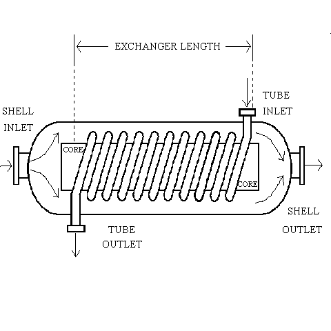

*Figure 1. Side view of helical-coil heat exchanger.*

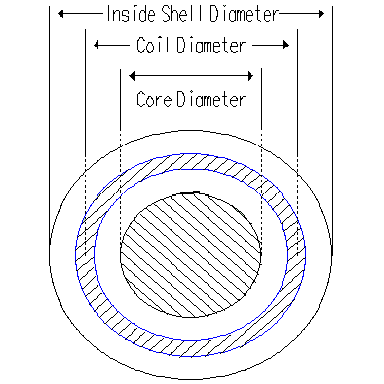

*Figure 2. Cross-section view of helical-coil heat exchanger.*

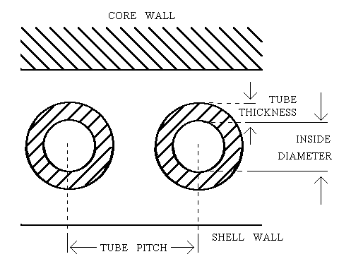

*Figure 3. Dimension of tubes in helical-coil heat exchanger.*

**Nomenclature**

- A - area (ft<sup>2</sup>)
- A<sub>f</sub> - Friedel coefficient
- Cp - specific heat of fluid (BTU/lb $^\circ$F)
- D<sub>c</sub> - coil diameter (ft)
- D<sub>s</sub> - inside shell diameter (ft)
- D<sub>t</sub> - inside tube diameter (ft)
- f - friction number
- Fr - Froude number
- g - gravitational acceleration (ft/sec<sup>2</sup>)
- g<sub>c</sub> - dimenstional constant (32.174 lb ft/lbf sec^2)
- h - heat transfer coefficient (BTU/ft<sup>2</sup> hr $^\circ$F)
- h<sub>d</sub> - fouling coefficient (ft<sup>2</sup> hr $^\circ$F/BTU)
- k - thermal conductivity (BTU ft hr $^\circ$F)
- L - length (ft)
- L<sub>tp</sub> - tube pitch (ft)
- m - total mass flux (lb/ft<sup>2</sup> hr)
- N<sub>c</sub> - number of coil turns or wraps
- Nu - Nusselt number
- P - pressure (psi)
- Pr - Prandtl number
- Q - net heat rate transfer (BTU/hr)
- r<sub>t</sub> - tube thickness (ft)
- Re - Reynolds number
- T - material temperature ($^\circ$F)
- U - overall heat transfer coefficient (BTU/ft<sup>2</sup> hr $^\circ$F)
- v - velocity (ft/hr)
- V - volumetric flowrate (ft<sup>3</sup>/hr)
- w - mass flowrate (lb/hr)
- We - Weber number
- x - vapor mass ratio
- $\rho$ - material density (lb/ft<sup>3</sup>)
- $\sigma$ - surface tension (lbf/ft)
- $\mu$ - fluid viscosity (’b/ft hr)

subscripts

- ave - average
- b - bulk
- core - core
- HX - heat exchanger
- i - entering in
- liq - liquid
- LM - log-mean
- o - exiting out
- s - shell-side material
- sol - solid
- t - tube-side material
- tot - total
- vap - vapor
- w - wall

```r
if (!require("pacman")) install.packages("pacman")
pacman::p_load(flextable, gdata, ggplot2, tidyverse)
data1 <- read.csv("HX_data.csv")
data2 <- read.csv("HX_data2.csv")
#
# create variables from data table
#
for (i in 1:nrow(data2)) {
  x <- data2[i,4]
  mv(from="x", to=data2[i,2])
}
FF_fp <- data1[7,3]                                       # fouling coefficient
FF_fs <- data1[7,5]                                       # fouling coefficient
data2[27,] <- list("fouling_coefficient_tube", "FF_fp", "ft2_hr_R/BTU", FF_fp)
data2[28,] <- list("fouling_coefficient_shell", "FF_fs", "ft2_hr_R/BTU", FF_fs)
ft <- flextable(data2) %>%
  theme_vanilla() %>%
  set_caption(caption = as_paragraph(
    as_b("Helical-Coil HX Example")))
ft
```

Helical-Coil HX Example

| description | parameter | unit | value |
| --- | --- | --- | --- |
| tube_inside_diameter | D_t | inch | 2.067 |
| coil_diameter | D_c | inch | 20.500 |
| shell_diameter | D_s | inch | 24.000 |
| core_inside_diamter | D_ci | inch | 17.000 |
| tube_thickness | r_t | inch | 0.154 |
| tube_pitch | D_tp | inch | 3.500 |
| thermal_conductivity_fluid_tube | k_ft | BTU/ft_hr_R | 0.365 |
| thermal_conductivity_tube | k_t | BTU/ft_hr_R | 30.000 |
| thermal_conductivity_fluid_shell | k_fs | BTU/ft_hr_R | 0.365 |
| flow_vapor_tube | F_tv | lb/hr | 160.500 |
| flow_liquid_tube | F_tl | lb/hr | 14,339.500 |
| flow_solid_tube | F_ts | lb/hr | 500.000 |
| density_vapor_tube | rho_tv | lb/ft3 | 0.202 |
| density_liquid_tube | rho_tl | lb/ft3 | 61.406 |
| density_solid_tube | rho_ts | lb/ft3 | 137.350 |
| density_fluid_shell | rho_s | lb/ft3 | 61.800 |
| specific_heat_fluid_tube | Cp_t | BTU/lb_R | 0.990 |
| specific_heat_fluid_shell | Cp_s | BTU/lb_R | 1.000 |
| viscosity_fluid_tube | mu_t | centipoise | 0.447 |
| viscosity_fluid_shell | mu_s | centipoise | 0.561 |
| viscosity_fluid__shell_wall | mu_w | centipoise | 0.600 |
| temperature_fluid_in_tube | Ti_t | F | 176.500 |
| temperature_fluid_out_tube | To_t | F | 140.000 |
| temperature_fluid_in_shell | Ti_s | F | 104.000 |
| temperature_fluid_out_shell | To_s | F | 140.800 |
| heat_transferred | Q | BTU/hr | 551,994.000 |
| fouling_coefficient_tube | FF_fp | ft2_hr_R/BTU | 0.001 |
| fouling_coefficient_shell | FF_fs | ft2_hr_R/BTU | 0.001 |

## Example

**Step 1: Calculating the tube-side heat-transfer coefficient.** For multi-phase flow, the approximate density of the fluid is calculated using the following equation (it assumes that there is no reduction in the fluid’s volume as a result of mixing the different phases):

$$\begin{equation}
\rho_{ave,t} = \frac {w_{tot,t}}{(
\frac {w_{sol,t}}{\rho_{sol,t}}+
\frac {w_{liq,t}}{\rho_{liq,t}}+
\frac{w_{vap,t}}{{\rho_{vap,t}}})}
\end{equation}$$

The velocity of the fluid within the tubes is needed, which is calculated by using the following equation:

$$\begin{equation}
v_{t} = \frac {w_{tot,t}}{\rho_{ave,t}\pi(\frac{D_{t}}{2})^2}
\end{equation}$$

Dimensionless correlations are needed to detennine the heat transfer coefficient. The Reynolds Number and Prandtl Number, defined below, are used for calculating the heat transfer coefficient:

$$\begin{equation}
Re_{t} = \frac {D_{t}v_{t}\rho_{ave,t}}{\mu_{t}}
\end{equation}$$

$$\begin{equation}
Pr_{t} = \frac {Cp_{t}\mu_{t}}{k_{t}}
\end{equation}$$

For turbulent flow in circular tubes, the Sieder-Tate equation is recommended[^3].

$$\begin{equation}
Nu_{t} = 0.023Re_{t}^{0.8}Pr_{t}^{1/3}(\frac {\mu_{b}}{\mu_{w}})^{0.14}
\end{equation}$$

Then, the inside heat transfer coefficient is calculated, using a correction for helical flow[^4].

$$\begin{equation}
h_{t} = (\frac {Nu_{t}k_{t}}{D_{t}})(1+3.5\frac{D_{t}}{D_{c}})
\end{equation}$$

```r
F_t <- F_tv + F_tl + F_ts                                 # total flow rate
rho_t <- F_t / (F_tv/rho_tv + F_tl/rho_tl + F_ts/rho_ts)  # fluid density
V_t <- 4*F_t / (pi*rho_t*(D_t/12)^2) / 3600               # fluid velocity
Re_t <- 124.02 * D_t*V_t*rho_t / mu_t                     # Reynold's number
Pr_t <- 2.419*Cp_t * mu_t / k_ft                          # Prandtl number
Nu_t <- 0.023*Re_t^0.8*Pr_t^(1/3)*(mu_t/mu_w)^0.14        # Nusselt number
h_i <- 12*Nu_t*k_ft/D_t * (1+3.5*D_t/D_c)                 # heat transfer coef
```

The total flow rate is 15,000 pounds per hour. The fluid density is 14.54 pounds per cubic feet. The fluid velocity is 12.3 feet per second. The Reynolds number is 102,543. The Prandtl number is 2.933. And, the Nusselt number is 322.3.

**The tube-side heat transfer coefficient is 924.09 BTU/ft<sup>2</sup>hr$^\circ$R.**

**Step 2: Calculating the shell-side heat-transfer coefficient.** The shell-side velocity is calculated by subtracting the area of the coiled tube from the core baffle.

Using this velocity, the Reynolds Number is calculated by using the outside diameter of the tube:

$$\begin{equation}
Re_{s} = \frac {(D_{t}+2r_{t})v_{s}\rho_{ave,s}}{\mu_{s}}
\end{equation}$$

For turbulent flow normal to a bank of non-staggered circular tubes, the following Nusselt Number is recommended[^5].

$$\begin{equation}
Nu_{s} = 0.26Re_{s}^{0.6}Pr_{s}^{1/3}
\end{equation}$$

Thus, the outside heat-transfer coefficient is calculated:

$$\begin{equation}
h_{s} = \frac {Nu_{s}k_{s}}{D_{t}+2r_{t}}
\end{equation}$$

```r
F_s <- Q / (Cp_s * (To_s-Ti_s))                           # flow rate
A_s <- pi*((D_s-2*(D_t+2*r_t))^2 - D_ci^2) / 576          # area
V_s <- F_s / (3600 * rho_s * A_s)                         # velocity
Re_s <- 124.02 * (D_t+2*r_t)*V_s*rho_s / mu_s             # Reynold's number
Pr_s <- 2.419*Cp_s * mu_s / k_fs                          # Prandtl number
Nu_s <- 0.26*Re_s^0.6*Pr_s^(1/3)                          # Nusselt number
h_o <- 12 * Nu_s*k_fs / (D_t + 2*r_t)                     # heat transfer coef
```

The total flow rate is 15,000 pounds per hour. The fluid density is 61.8 pounds per cubic feet. The fluid velocity is 0.15 feet per second. The Reynolds number is 4,918. The Prandtl number is 3.718. And, the Nusselt number is 66.1.

**The shell-side heat transfer coefficient is 121.88 BTU/ft<sup>2</sup>hr$^\circ$R.**

**Step 3: Calculating the heat-exchanger size.** rior to determining the overall heat-transfer coefficient, one needs to calculate the log mean diameter of the tubes[^6].

$$\begin{equation}
D_{LM} = \frac {2r_{t}}{ln(\frac{D_{t}+2r_{t}}{D_{t}})}
\end{equation}$$

The overall heat transfer coefficient is needed. It accounts for the tube-side heat-transfer coefficient, and the fouling coefficient, shell-side heat-transfer coefficient and fouling coefficient, and the thermal conductivity of the tube[^7].

The last parameter needed to calculate the surface area needed inside the heat exchanger is the mean temperature difference. Because this type of exchanger exhibits an actual one-pass counter-current flow, the mean temperature difference is equal to the log mean temperature difference calculation[^8].

$$\begin{equation}
\Delta T_{LM} = \frac {(T_{i,t}-T_{o,s})-(T_{o,t}-T_{i,s})}
{ln(\frac{T{i,t}-T{o,s}}{T{o,t}-T_{i,s}})}
\end{equation}$$

The heat transfer surface area is calculated as:

$$\begin{equation}
A = \frac {Q} {U\Delta T_{LM}}
\end{equation}$$

The linear length of the tube is:

$$\begin{equation}
L_{p} = \frac {A} {\pi D_{t}}
\end{equation}$$

And, the length of the heat exchanger is calculated as:

$$\begin{equation}
L_{HX} = \frac {L_{p}L_{t,p}} {\pi D_{c}}
\end{equation}$$

```r
D_LM <- 2*r_t / log((D_t+2*r_t)/D_t)                      # log mean tube diameter
U <- 1/h_i + r_t*D_t/(12*k_t*D_LM) + D_t/(h_o*(D_t+2*r_t))
U <- U + FF_fp + FF_fs*D_t/(D_t+2*r_t)
U <- 1/ U                                                 # overall heat transfer
T_LM <- (Ti_t-To_s-To_t+Ti_s)/log((Ti_t-To_s)/(To_t-Ti_s))# log mean temperature
A <- Q / (U * T_LM)                                       # heat exchanger area
L_p <- 12 * A / (pi*D_t)                                  # tube length
L_HX <- L_p*D_tp / (pi*D_c)                               # heat exchanger length
Nc <- 12 * L_HX / D_tp                                    # number of coils
```

The overall heat transfer coefficient is 95.31 BTU/ft<sup>2</sup>hr$^\circ$R. The heat exchanger area is 161.55 square feet. The tube length is 299 feet. The heat exchanger length is 16 feet. And, the number of tube coils is 56.

**Comments**

# Notes

[^1]: Haraburda, Scott (July 1, 1995), “[Three-phase flow? Consider helical-coil heat exchangers](https://www.chemengonline.com/articles.php?file=1985-1999/Vol102/chevol102_num7_68.html),” Chemical Engineering volume 102, number 7 pp. 149-151.
[^2]: Patil, R.; Shende, B.; and Ghosh, P. (Dec. 13, 1982), “Designing a Helical-Coil Heat Exchanger,” Chemical Engineering.
[^3]: Crawford, H.B. and Eckes, B.E., eds (1984). Perry’s Chemical Engineers’ Handbook.McGraw-Hill Book Co: New York, NY. See equation 10-50.
[^4]: Jeschke, H. (1925). “Wärmeübergang und Druckverlust in Rohrschlangen. Beiheft,” Technische. Mechanik 69. pp.24-28
[^5]: Crawford and Eckes. See equation 10-71
[^6]: Bennett, C.O. and Myers, J.E. (1982) Momentum, Heat, and Mass Transfer, McGraw Hill: New York. see equation 18-9
[^7]: Crawford and Eckes. See equation 10-31
[^8]: Crawford and Eckes. See equation 10-118a